# Chronic Illness and Depression: Prevalence Comorbidity & Costs

# Abstract

Depression, studies have shown, costs society $210 billion per year in direct and indirect medical expenditures and lost productivity. In fact, research has indicated that the productive years lost to disability from depression are three times greater than from those to diabetes, eight times greater than those from heart disease, and 40 times those to cancer. Furthermore, patients suffering from chronic illness with co-occurring depression may incur upwards of 50% to 100% greater use in of health care services and costs. This analysis explores the sociodemographics of depression, its co-occurrence with chronic illness, and the marginal, conditional and joint effects of depression and chronic disease on productivity and the use of health care services.

The Center for Disease Control’s 2013 Behavioral Risk Factor Surveillance System (BRFSS) telephone survey provided the data for this analysis. This state-based, chross-sectional study compiled health, chronic disease, quality of life, behavioral risk factor and use of health service information from nearly 500,000 Americans. The data was statistically investigated to address four fundamental questions: (1) is there a relationship between socioeconomic status depression, (2) to what degree does depression co-occur with other chronic conditions such as heart disease, diabetes, asthma, kidney disease, asthma and other lung diseases, (3) what are the marginal, conditional, and joint effects of depression on productivity vis-a-vis those of chronic illness and (4) how does depression affect the use of health care services for those with and without chronic disorders.

Though these findings were significant, further time-based studies which evaluate multiple interventions would be required to illuminate the direction, strength, and nature of any cause-effect relationships among sociodemographic, productivity, and cost factors.

Notwithstanding, this analysis has shown depression to be the most debilitating of the chronic disorders, with significant productivity effects and personal and societal costs.

# Introduction

## Background Information

Depression in America costs society $210 billion per year in direct and indirect medical expenditures and lost productivity (Greenberg et al. 2015). In fact, productive years lost to disability from depression are three times greater than from diabetes, eight times more than from heart disease, and 40 times that of cancer (Lim et al. 2012). Causing persistent (two weeks or longer) feelings of sadness and loss of interest in activities once enjoyed, feelings of worthlessness or guilt, difficulty thinking, concentrating, or decision making, and thoughts of death or suicide (American Psychiatric Association 2017), depression afflicts more than 18% (Bekiempis 2014) of Americans. Over 16 million adults aged 18 or older (6.7% of all U.S. adults) had at least one major depressive episode during 2015 (Center for Behavioral Health Statistics and Quality 2016). According to the World Health Organization, depression is **the** leading cause of disability worldwide (WHO 2012) and carries the heaviest burden of disability among adults age 15 to 44 in the United States (Health and States 2010).

Notwithstanding, the economic burden of chronic disease, the leading cause of death and disability in America, tops $1.3 trillion annually in lost productivity and treatment costs (Devol and Bedroussian 2007). Whereas, sixty percent of Americans, according to a 2014 report, had at least one chronic disease, 42% of U.S. citizens suffered from several chronic conditions (Buttorff, Ruder, and Bauman 2017) and the treatment costs are substantial. Health care spending for chronic illnesses, such as coronary heart disease, stroke, asthma, cancer, chronic obstructive pulmonary disease (COPD), kidney disease, diabetes and mental disorders, is $1.65 trillion per annum, 75% of overall health care spending.

Hypothesized to have a greater prevalence among the lower social-economic strata, depression often co-occurs with other chronic diseases and is consistently associated with increased overall burden of illness in patients. Indeed, patients suffering from chronic diseases with co-occurring depression can have a 50% to 100% increase in overall health services use and costs (Simon, VonKorff, and Barlow 2003).

This analysis explores the socioeconomics of depression, its relationship with chronic illness, and the marginal and joint effects of depression and chronic illness on productivity and the use of health care services. Capturing the health conditions, behavioral risk factors, quality of life and use of preventative services for nearly 500,000 Americans, the Center for Disease Control’s 2013 state-based, monthly cross-sectional Behavioral Risk Factor Surveillance System (BRFSS) telephone survey served as the data source for this analysis.

## Research Questions

Four research questions were devised to examine the socioeconomics of depression, the relationship between depression and chronic illness and their marginal and joint effects on productivity and the use of health care services.

### Research Question #1: Socioeconomic Factors

The first research question assessed the relationship between depressive disorder and socioeconomic status as measured by educational achievement and income.

> Is there an association between education and income and the prevalence of depression?

A diagnosis of depression was the response variable, and education level completed and income level achieved were the explanatory variables.

### Research Question #2: Co-occurrence of Depression and Chronic Illness

This research question examined the degree of co-occurrence of depression and chronic illness.

> Is there a relationship between depression and chronic illness?

The response variable was the diagnosis of depression and the diagnosis of a chronic illness explanatory variable, which was set to “Yes” if any of the following variables were set to “Yes.”

Table 1: Chronic conditions evaluated in this study

| X. | BRSS.Variable | Desc | Type | Subtype |
| --- | --- | --- | --- | --- |
| 1 | cvdinfr4 | Ever Diagnosed With Heart Attack? | Categorical | Dichotomous |
| 2 | cvdcrhd4 | Ever Diagnosed With Angina Or Coronary Heart Disease? | Categorical | Dichotomous |
| 3 | cvdstrk3 | Ever Diagnosed With A Stroke? | Categorical | Dichotomous |
| 4 | asthma3 | Ever Told Had Asthma? | Categorical | Dichotomous |
| 5 | chcscncr | Ever Told You Had Skin Cancer? | Categorical | Dichotomous |
| 6 | chcocncr | Ever Told You Had Any Other Types Of Cancer? | Categorical | Dichotomous |
| 7 | chccopd1 | Ever Told You Have Copd Chronic Obstructive Pulmonary Disease, or Emphysema? | Categorical | Dichotomous |
| 8 | havarth3 | Ever Told You Have Arthritis? | Categorical | Dichotomous |
| 9 | chckidny | Ever Told You Have Kidney Disease? | Categorical | Dichotomous |
| 10 | diabete3 | Ever Told You Have Diabetes? | Categorical | Dichotomous |

### Research Question #3: Depression, Chronic Illness and Loss of Productivity

The literature associates both depression and chronic disease with significant loss of productivity. This research question examined the marginal and joint effects of depression and chronic illness on productivity.

> To what degree does depression with co-occurring chronic illness affect productivity, vis-a-vis that of diagnoses of depression or chronic illness separately?

The response variable was the number of sick days over the 30 days preceding the survey, and the explanatory variables were a diagnosis of depression and a diagnosis of one or more chronic conditions.

### Research Question #4: Chronic Illness, Depression and Costs

Co morbidity of depression and chronic disease is associated with significantly higher usage of health care services. This research question examined the marginal and joint effects of depression and chronic illness on the use of health care services.

> Is there a relationship between depression, chronic disease and the use of health care services?

The response variable was the number of Dr. visits during the 12 months preceding the survey. The explanatory variables were the diagnoses of depression and chronic illness.

## Document Organization

The methods section describes the data, its collection process, sampling techniques and data preprocessing as well as the univariate and multivariate analyses for each research question. The results section summarizes the descriptive and analytical statistics. The discussion section describes the significance of the findings vis-a-vis currently available research. Lastly, the conclusion synthesizes the key points.

# Methods

## Data

The analysis used survey data obtained from the 2013 Behavioral Risk Factor Surveillance System (BRFSS), a state-based, monthly cross-sectional telephone survey, conducted with technical and methodological assistance from the Centers for Disease Control and Prevention (CDC). The study queried U.S. residents regarding their health-related risk behaviors, chronic health conditions, and use of preventive services. Comprised of over 490,000 responses from all 50 states, the District of Columbia, Guam and Puerto Rico, the BRFSS data captured over 300 factors such as tobacco use, HIV/AIDS knowledge and prevention, exercise, immunization, and health status. The compendium recorded sick days, health-related quality of life, health care access, inadequate sleep, hypertension awareness, cholesterol awareness, chronic health conditions, alcohol use, fruit and vegetable consumption, arthritis burden, and seat-belt use.

### Data Sampling

Disproportionate stratified sampling (DSS) was used to ensure that the selection of respondents was representative of the population of non-institutionalized adult U.S. residents age 18 and older. The CDC sampled from two landline telephone number strata which were based upon the presumed density of known telephone household numbers in the sample; the high-density landline strata were sampled at a higher rate. The researchers randomly selected mobile phone numbers from a collection of confirmed mobile phone area code and prefix combinations. Next, the investigators randomly chose respondents from each stratum with equal probability of selection. The CDC provided separate phone samples for each state based upon the target number of completed surveys for that state that year. As such, the data and observations could be considered **generalizable** to the population of adults age 18 and older, living in the U.S. Causation, on the other hand, could not be inferred as there was no random assignment of participants to control and experimental groups.

### Data Sampling Bias

Elements of the survey sampling protocol were designed to mitigate *noncoverage bias*, *nonresponse bias* and *response biases*. Weighting protocols were used to adjust for nonresponse bias and to assure representativeness across population characteristics such as education level, marital status, and home ownership. **Stratum weights** accounted for differences in the probability of selection among strata. The **design weight** was the product of the stratum weight and the inverse of the number of telephones in the household. Finally **raking** adjusted the design weight according to age group by gender, race/ethnicity, education, marital status, tenure, gender by race/ethnicity, age group by race/ethnicity and phone ownership. Recent adjustments to the protocol have been made to account for the increasing number of adults with only mobile phones.

However, *selection bias*, *partial-response bias* and *social desirability bias* may have manifested. Selection bias may result as a consequence of the telephone number selection process. The increased use of mobile phones and the sociodemographics characteristics of telephone listing could have disproportionately favored certain social-economic, age or ethnic groups. The generalizability could have been affected by partial response bias. For instance, the poor health variable had a response rate of slightly over 50%. Partial response bias may have reduced available sample size, reduced power, and lead to type II errors. Social desirability may have been extant in higher than actual levels of education or income, or a reluctance on behalf of the respondent to admit to certain unhealthful behaviors or activities. Instead, his or her responses may have been biased towards attitudes, beliefs, habits, and behaviors believed to be socially desirable.

### Data Questionnaire

The BRFSS questionnaire, designed by a working group of BRFSS state coordinators and CDC staff and approved by all state coordinators, had three parts: 1) the core component, consisting of the fixed core, rotating core, and emerging core, 2) optional modules, and 3) state-added questions. The core component questions were mandatory, but the modules were optional. The fixed core, a standard set of questions regarding demographics and current health behaviors, were asked by all states. The rotating core, made up of two distinct sets of questions, each set used in alternating years by all states, addressed different topics. In the years the rotating core topics were not used, they were offered as optional modules. The emerging core, a set of up to five questions typically focused on “late -breaking” issues, was added to the fixed and rotating cores.

### Data Collection

States conducted telephone interviews during daytime and evening hours, seven days per week, during each calendar month. The core portion of the interview lasted approximately 18 minutes, and the state modules added another 5-10 minutes to the interview.

### Data Variables

The following table lists the variables used as well as any “derived” variables created for the analysis.

Table 2: BRFSS variables used in the study

| X. | BRSS.Variable | Study.Variable | Desc | Type | Subtype | Source |
| --- | --- | --- | --- | --- | --- | --- |
| 1 | addepev2 | Depression | Ever Told You Had A Depressive Disorder | Categorical | Dichotomous | Survey |
| 2 | poorhlth | BadDays | Poor Physical Or Mental Health | Quantitative | Discrete | Survey |
| 3 | X_incomg | Income | Computed Income Categories | Quantitative | Ordinal | Survey |
| 4 | X_educag | Education | Computed Level Of Education Completed Categories | Quantitative | Ordinal | Survey |
| 5 | drvisits | Visits | Doctor Visits Past 12 Months | Quantitative | Discrete | Survey |
| 6 | chronic | Chronic | Ever Diagnosed with a Chronic Disease | Categorical | Dichotomous | Derived |
| 7 | poorhlth | BadDaysTransformed | Box-Cox Transformation of BadDays Variable | Quantitative | Continous | Derived |
| 8 | poorhlth | BadDaysRange | Categorized BadDays Variable | Categorical | Interval Data | Derived |
| 9 | cvdinfr4 | NA | Ever Diagnosed With Heart Attack | Categorical | Dichotomous | Survey |
| 10 | cvdcrhd4 | NA | Ever Diagnosed With Angina Or Coronary Heart Disease | Categorical | Dichotomous | Survey |
| 11 | cvdstrk3 | NA | Ever Diagnosed With A Stroke | Categorical | Dichotomous | Survey |
| 12 | asthma3 | NA | Ever Told Had Asthma | Categorical | Dichotomous | Survey |
| 13 | chcscncr | NA | (Ever Told) You Had Skin Cancer? | Categorical | Dichotomous | Survey |
| 14 | chcocncr | NA | (Ever Told) You Had Any Other Types Of Cancer? | Categorical | Dichotomous | Survey |
| 15 | chccopd1 | NA | (Ever Told) You Have (Copd) Chronic Obstructive Pulmonary Disease, Emphysema Or | Categorical | Dichotomous | Survey |
| 16 | havarth3 | NA | Told Have Arthritis | Categorical | Dichotomous | Survey |
| 17 | chckidny | NA | (Ever Told) You Have Kidney Disease? | Categorical | Dichotomous | Survey |
| 18 | diabete3 | NA | (Ever Told) You Have Diabetes | Categorical | Dichotomous | Survey |

### Data Preprocessing

After reducing the data set from 330 variables to 15, two new variables were coded. The dichotomous ‘Chronic’ variable indicated a diagnosis of one or more chronic conditions. The dichotomous ‘SickDaysInd’ variable indicated that one or more sick days were reported.

### Power Analysis

Variable and partial response rates may have affected sample size. To ensure that readers could rely upon non-significant results, this analyst conducted several power analyses using the pwr package (Ekstrom et al. 2017). Each test indicated the minimum sample size required to detect a small effect of 0.1, with the $p < .05$ probability of a type I error of p < .05 and power of 0.8. Table 3 summarizes the minimum required sample size ($N$) for each type of statistical test to be conducted.

Table 3: Sample Size Estimates from Power Analysis

| Method | N | Power | Significance |
| --- | --- | --- | --- |
| Income Chi squared power calculation | 1193.53 | 0.8 | 0.05 |
| Education Chi squared power calculation | 1090.26 | 0.8 | 0.05 |
| Two-sample t test power calculation | 1570.73 | 0.8 | 0.05 |
| Balanced one-way analysis of variance power calculation | 393.41 | 0.8 | 0.05 |

## Data Analysis

The study involved both descriptive and inferential statistics.

### Descriptive Statistics

The study began with a univariate analysis of the sample variables of interest. For the categorical variables, response rates, proportions and frequency counts were calculated and presented in tables and bar plots. Population proportions were estimated using one-proportion z-tests. For quantitative variables, ranges, medians, means, modes, quartiles, skewness, kurtosis, standard deviations, standard errors and extreme values were obtained and presented in tables, box plots, and histograms/density plots.

### Inferential Statistics

One-proportion z-tests were conducted to ascertain the differences between observed rates of depression and chronic illness, and the hypothesized rates from literature. The marginal associations between income and education and the prevalence of depression and the association between depression and chronic illness diagnoses were evaluated using chi-squared equality of proportions tests. The Cochran-Mantel Haenszel test evaluated the conditional association of income on depression, controlling for education. Since the quantitative variables departed significantly from normality, non-parametric Mann-Whitney-Wilcoxon tests (Mann and D.R., n.d.) and Kruskal-Wallis (Kruskal and Wallis 1952) tests were administered to determine the marginal and joint effects of depression and chronic illness on the mean number of sick days and Dr. visits reported. Odds ratios indicated the strength of association between categorical variables. Association tests using the Cramer’s V statistic were administered to measure the effect sizes on categorical response variables. The Cramer’s D statistic, provided by the Kolmogorov-Smirnov test, estimated effect sizes on quantitative variables. The $\alpha$ significance level was uniformly set to .05 for all statistical tests. Table 4 summarizes the inferential techniques employed in this analysis.

Table 4: Inferential Techniques

| Inference | Analysis.Type | Research Question Q1 | Research Question Q2 | Research Question Q3 | Research Question Q4 | Test |
| --- | --- | --- | --- | --- | --- | --- |
| Difference in Proportions | Univariate | X | X |  |  | One-proportion z-test |
| Difference in Proportions | Bivariate | X | X |  |  | Chi-squared test of equal proportions |
| Strength of Association | Multivariate | X | X |  |  | Odds Ratios |
| Strength of Association (Categorical) | Multivariate | X | X |  |  | Association Test (Cramer’s V) |
| Conditional Independence | Multivariate |  |  | X | X | Cochran–Mantel–Haenszel |
| Difference in Means(2 Groups) | Bivariate |  |  | X | X | Mann-Whitney-Wilcoxon test |
| Difference in Means (> 2 Groups) | Multivariate |  |  | X | X | Kruskal–Wallis test |
| Effect Size (Categorical on Quantitative) | Multivariate |  |  | X | X | Kolmogorov-Smirnov (Cramer’s D) |

## System and Environment

This analysis was implemented using the 64 bit version of the R Programming Language, version 3.3.1. (The R Foundation 2015) within the R. Studio Version 0.99.903 (Rstudio Team 2016) development environment on a Windows x64-based laptop powered by an Intel Core i7-3610QM CPU @ 2.30GHz, 2301 MHz processor with 4 Cores, 8 Logical Processors, and 16.0 GB of installed memory, running the Microsoft Windows 10 Home operating system, version 10.0.14393 Build 14393. Report writing and generation packages included knitr (Xie 2013), printr (Yihui 2017), and kfigr (Koohafkan 2015). Data management functionality was provided by the dplyr [Wickham2015a], reshape2 (Rcpp 2016), xtable (Dahl and Scott 2016) and data table (Dowle 2016) packages. Graphics and data visualization were powered by the ggplot2 (Wickham 2016), gridExtra (Baptiste Auguie 2016), the stargazer (Hlavac et al. 2015), vcd (Meyer et al. 2013), and effects (Fox 2009) packages. Additional statistical packages included modeest (Ponset, n.d.) and pwr (Ekstrom et al. 2017).

# Results

The socioeconomics of depression, the relationship between depression and the occurrence of one or more chronic conditions, and the marginal and joint effects of depression and chronic illness on productivity and the use of health care services are addressed here via the following four questions:

1. Is there an association between education and income and the prevalence of depression?
2. Is there a relationship between depression and chronic illness?
3. Is there a relationship between depression and chronic disease and productivity?
4. Is there a relationship between depression and chronic conditions and the use of health care services?

The rest of this section begins with a univariate analysis of the categorical and quantitative variables examined in the study. Then, the investigational results of each research question are presented, including the univariate and multivariate analyses of marginal and joint effects of depression and chronic illness on productivity and the use of health services.

## Univariate Analysis

For categorical variables, response rates, category frequencies, and proportions, differences in proportions and effect sizes are reported. Descriptive statistics are presented for the two quantitative variables: doctor visits, and sick days.

### Categorical Variables

Average valid response rate, as indicated in Table 5, was 96%, for all variables.

Table 5: Summary of Univariate Analysis: Categorical Variables

| Variable | BRFSS | Levels | Responses | Valid | NAs | Rate |
| --- | --- | --- | --- | --- | --- | --- |
| Depression | addepev2 | 2 | 491775 | 489486 | 2289 | 99.53 |
| Income | X_incomg | 5 | 491775 | 420347 | 71428 | 85.48 |
| Education | X_educag | 4 | 491775 | 489495 | 2280 | 99.54 |
| Chronic | <derived> | 2 | 491775 | 491775 | 0 | 100.00 |

#### Depression Variable

Of the 491,775 responses, 489,486 were valid yielding a response rate of approximately 100%. As indicated in Figure 1, the prevalence of diagnoses of depression was 19.5%.

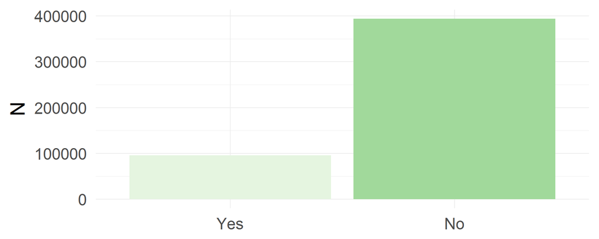

| Depression | N | Pct | Cumulative |
| --- | --- | --- | --- |
| Yes | 95779 | 19.5 | 19.5 |
| No | 393707 | 80.1 | 99.6 |
| NA | 2289 | 0.5 | 100.1 |
| Total | 491775 | 100.1 |  |

Figure 1: Frequency distribution of diagnoses of depression

An estimated $p =$ 18.2 percent of the American population suffers from depression (Bekiempis 2014). A one-proportion z-test was conducted, with a significance level of $\alpha$ = .05, to estimate the difference between the hypothesized proportion, $p$, and the observed proportion, $\hat{p}$ = 19.5 under the following hypotheses:

$H_0$ $p = \hat{p}$  
$H_a$ $p \neq \hat{p}$

#### Chronic Illness Variable

The ‘Chronic’ variable, as characterized in Figure 2, was derived from the ten categorical dichotomous variables with a collective response rate of 100%. The percent of respondents reporting a diagnosis of one or more chronic conditions was 56.3%.

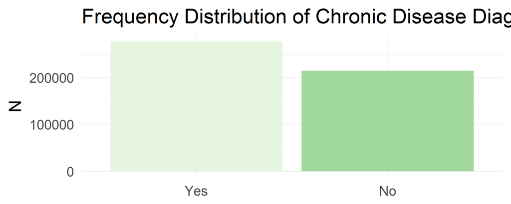

| Chronic | N | Pct | Cumulative |
| --- | --- | --- | --- |
| Yes | 276916 | 56.3 | 56.3 |
| No | 214859 | 43.7 | 100 |
| Total | 491775 | 100.0 |  |

Figure 2: Frequency distribution of diagnoses of chronic illness

$H_0$ $p = \hat{p}$  
$H_a$ $p \neq \hat{p}$

#### Income Variable

The ‘Income’ variable, a five level ordinal categorical variable, had a response rate of 85%, leaving a total sample size of 420,347. The frequency distribution is summarized in Figure 3.

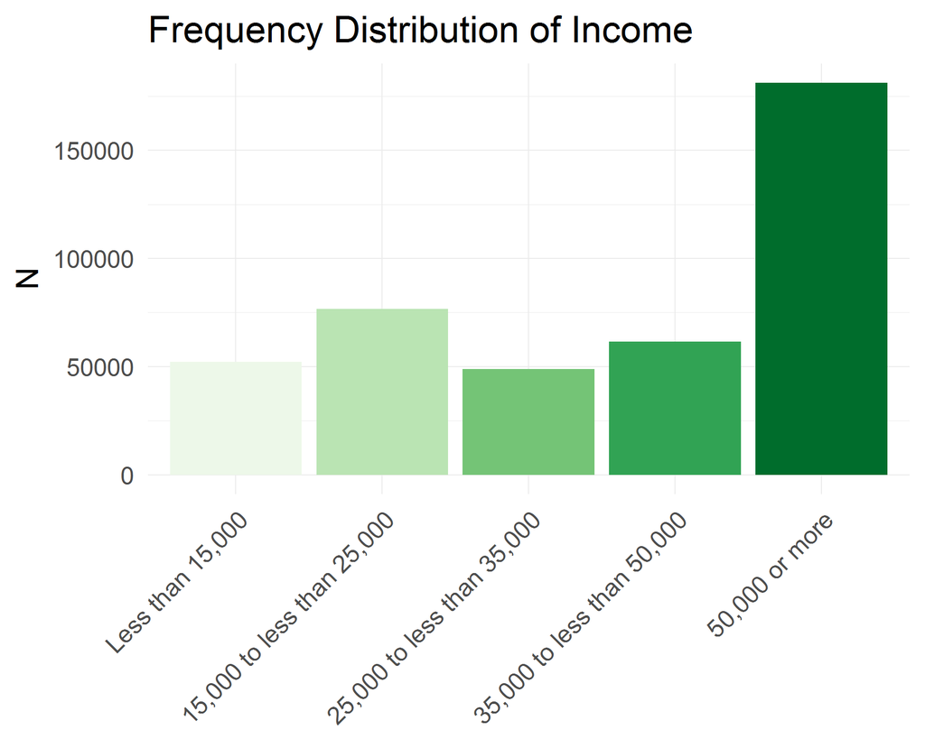

| Income | N | Pct | Cumulative |
| --- | --- | --- | --- |
| Less than 15,000 | 52235 | 10.6 | 10.6 |
| 15,000 to less than 25,000 | 76606 | 15.6 | 26.2 |
| 25,000 to less than 35,000 | 48867 | 9.9 | 36.1 |
| 35,000 to less than 50,000 | 61508 | 12.5 | 48.6 |
| 50,000 or more | 181131 | 36.8 | 85.4 |
| NA | 71428 | 14.5 | 99.9 |
| Total | 491775 | 99.9 |  |

Figure 3: Frequency distribution of income levels

#### Education Variable

The ‘Education’ variable, a four level ordinal categorical variable, had a response rate of approximately 100%, leaving a total sample size of 489,495. The frequency distribution is summarized in Figure 4.

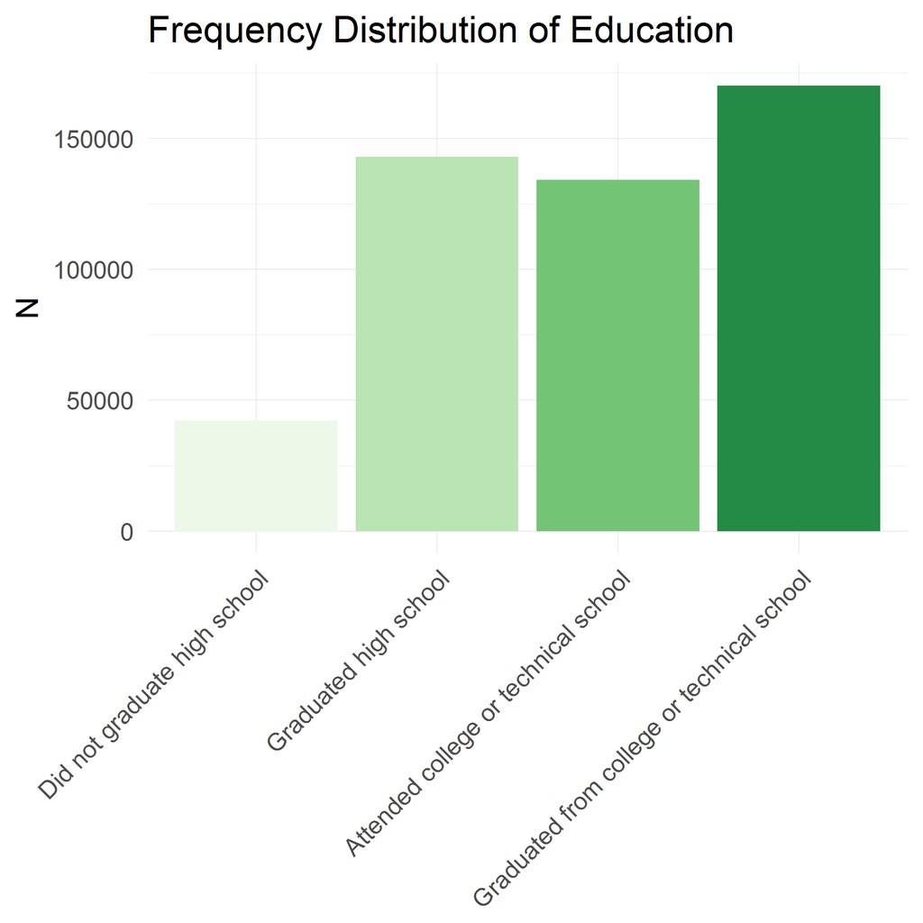

| Education | N | Pct | Cumulative |
| --- | --- | --- | --- |
| Did not graduate high school | 42213 | 8.6 | 8.6 |
| Graduated high school | 142968 | 29.1 | 37.7 |
| Attended college or technical school | 134196 | 27.3 | 65 |
| Graduated from college or technical school | 170118 | 34.6 | 99.6 |
| NA | 2280 | 0.5 | 100.1 |
| Total | 491775 | 100.1 |  |

Figure 4: Frequency distribution of education level completed

### Quantitative Variables

The descriptive statistics, distributions, outliers, spread, central tendencies, skew and kurtosis of the sick days and Dr. visits variables are summarized below.

#### Sick Days Variable

As shown in Table 6, the SickDays variable had a response rate of 50.6%, reducing the available sample size to 248,621 observations. Significant right skew, signaled by the difference between the mean and median, and confirmed by the skew and kurtosis measurements, was extant.

Table 6: Descriptive Statistics for Sick Days Variable

| Variable | BRFSS | N | Valid | Response Rate | Min | Lower | Median | Mean | Mode | CI | Upper | Max | SD | SE | Skew | Kurtosis |
| --- | --- | --- | --- | --- | --- | --- | --- | --- | --- | --- | --- | --- | --- | --- | --- | --- |
| SickDays | poorhlth | 491775 | 248621 | 50.6 | 0 | 0 | 0 | 5 | 0 | 0.037 | 5 | 30 | 9 | 0.02 | 1.81 | 1.86 |

The distribution of sick days, characterized in Figure 5, included 141,506 respondents (56.9%) who reported zero sick days. To better reveal the distribution, reports of zero sick days were removed, and the new distribution is rendered in Figure 6.

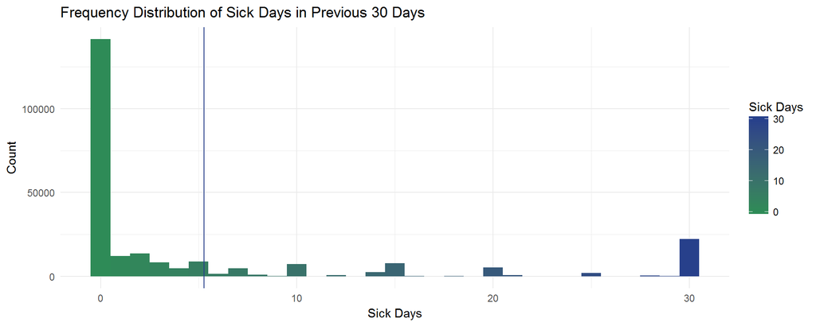

Figure 5: Histogram of sick days reported during the previous 30 days

As shown in Figure 6, the average number of sick days, among those reporting one or more sick days, was 12, with a median of 7 sick days. The plurality was 30 sick days.

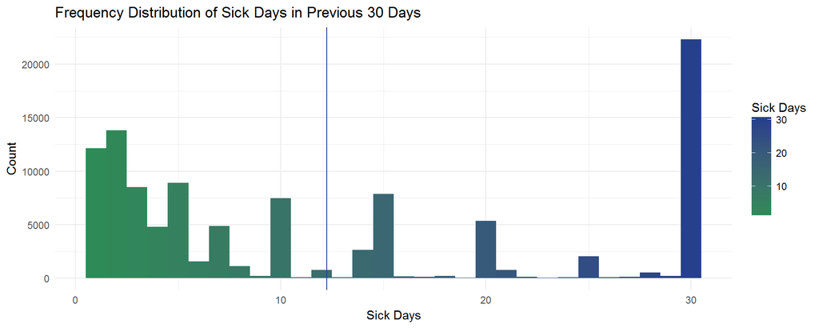

Figure 6: Histogram of one or more sick days during the previous 30 days

#### Visits Variable

The Visits variable, as shown in Table 7, had a slightly higher response rate of 69%, reducing the available sample size to 337,623 observations. The distribution, $Med$ = 3, $\bar{x}$ = 5.24, $SD$ = 8.3, was also significantly right-skewed.

Table 7: Descriptive Statistics for Dr. Visits Variable

| Variable | BRFSS | N | Valid | Response Rate | Min | Lower | Median | Mean | Mode | CI | Upper | Max | SD | SE | Skew | Kurtosis |
| --- | --- | --- | --- | --- | --- | --- | --- | --- | --- | --- | --- | --- | --- | --- | --- | --- |
| Visits | visits | 491775 | 337623 | 69 | 0 | 1 | 3 | 5.24 | 2 | 0.028 | 6 | 76 | 8.3 | 0.01 | 4.77 | 29.96 |

As presented in Figure 7, 35,453 respondents (10.5% of valid responses) reported zero Dr. visits during the year preceding the survey.

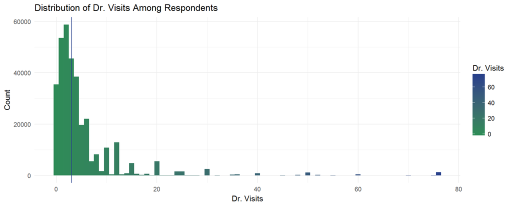

Figure 7: Histogram of the number of Dr. visits during previous 12 months

## Research Question 1: Depression Sociodemographics

### Depression and Income (Marginal Association)

This analysis found that depression was inversely associated with income, $X^2$ = 11,501.38, $N$ = 418,325, $df$ = 10, $p < .001$ and a strength of 0.059.

The combined response rate of the Depression and Income variables was 85.1%, yielding 418,325 completed cases for analysis. Table 8 and Table 9 show the frequencies and proportions, respectively, of depression diagnoses for each income level.

Table 8: Marginal contingency table of frequencies of depression diagnoses by income level

|  | Depression | Yes | No | Sum |
| --- | --- | --- | --- | --- |
| Income |  |  |  |  |
| Less than 15,000 |  | 17,938 | 33,799 | 51,737 |
| 15,000 to less than 25,000 |  | 18,844 | 57,253 | 76,097 |
| 25,000 to less than 35,000 |  | 9,600 | 38,999 | 48,599 |
| 35,000 to less than 50,000 |  | 11,050 | 50,211 | 61,261 |
| 50,000 or more |  | 26,327 | 154,304 | 180,631 |
| Sum |  | 83,759 | 334,566 | 418,325 |

Table 9: Marginal contingency table of proportions of depression diagnoses by income level

|  | Depression | Yes | No |
| --- | --- | --- | --- |
| Income |  |  |  |
| Less than 15,000 |  | 0.3467151 | 0.6532849 |
| 15,000 to less than 25,000 |  | 0.2476313 | 0.7523687 |
| 25,000 to less than 35,000 |  | 0.1975349 | 0.8024651 |
| 35,000 to less than 50,000 |  | 0.1803758 | 0.8196242 |
| 50,000 or more |  | 0.1457502 | 0.8542498 |

Of those respondents who reported income, 83,759 (20.02%) indicated a prior diagnosis of depression. Stated in Table 9 and further clarified in Figure 8, rates of depression were inversely associated with income.

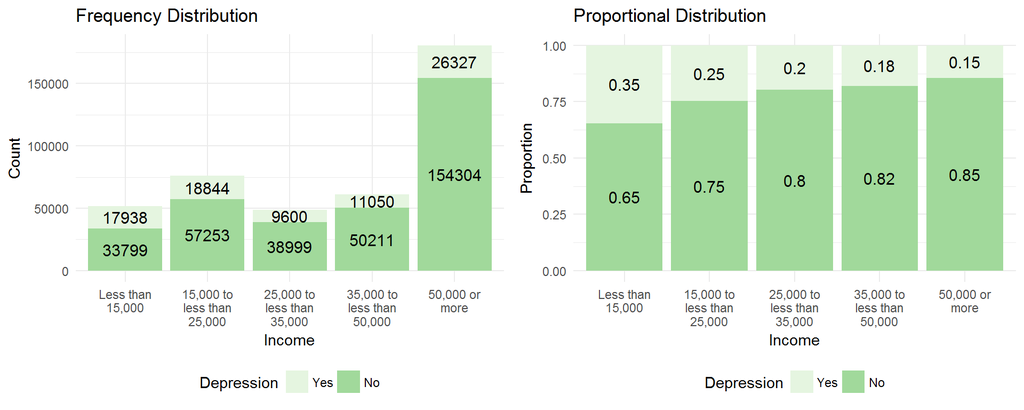

Figure 8: Marginal frequencies and proportions of depression diagnoses by income level

The mosaic plot below graphically depicts the association between depression diagnoses and financial compensation levels, vis-a-vis the independence model.

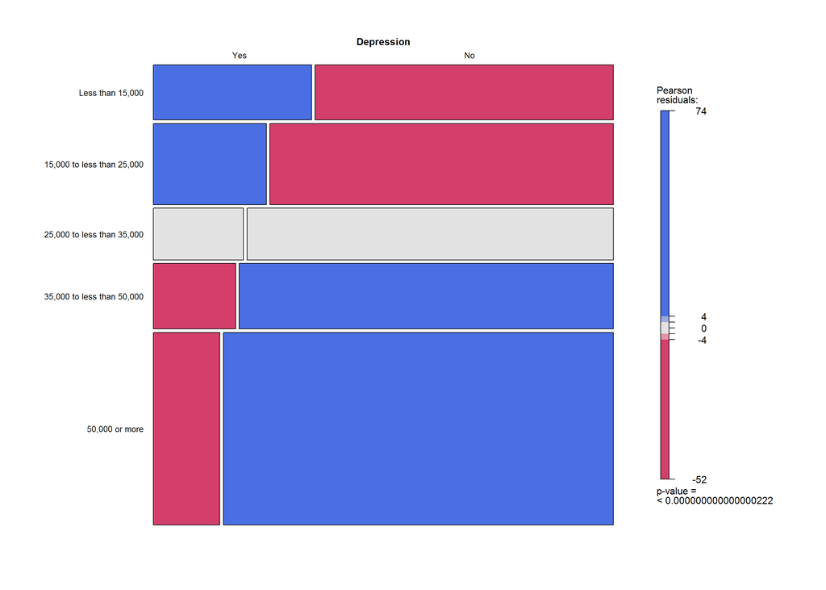

Figure 9: Mosaic plot of marginal relationship between depression and income

In Figure 9, the width of the bars indicates the relative proportion of respondents at each income level that either had or had not a diagnosis of depression. For instance, the “50,000 or more” income level had the smallest proportion of respondents with a diagnosis of depression. The height of the bars connotes the percentage of the overall responses by salary level. The colors express residuals from the Pearson chi-square model of independence. Blue implies that observed frequencies were greater than expected for independence. Red suggests fewer observations than expected. Grey denotes that observed and expected frequencies were approximately equal. To sum, the observed frequencies of depression diagnoses for the two lowest income categories were greater than expected assuming independence. The two highest income levels had too few. The 25,000 to 35,000 income level frequencies were approximately equal to expected.

The differences in proportions were tested for statistical significance with a chi-squared at a significance level of $\alpha$ = .05, under the following hypotheses:

$H_0$: Diagnoses of depression and income level are independent  
$H_a$: Diagnoses of depression and income level are not independent

The differences in proportions were statistically significant, $X^2$ = 11,501.38, $N$ = 418,325, $df$ = 10, and $p < .001$. The strength of the association using Cramer’s V (Hoel, Wolfowitz, and Cramer 1947) was 0.059. Nonetheless, the null hypothesis was rejected in favor of the alternative hypothesis of the association between depression and income.

Table 10: The marginal odds ratios of a diagnosis of depression by income level

| Dimension | Odds |
| --- | --- |
| Less than 15,000:15,000 to less than 25,000/Yes:No | 1.61 |
| 15,000 to less than 25,000:25,000 to less than 35,000/Yes:No | 1.34 |
| 25,000 to less than 35,000:35,000 to less than 50,000/Yes:No | 1.12 |
| 35,000 to less than 50,000:50,000 or more/Yes:No | 1.29 |

In conclusion, this analysis has shown that rates of depression were inversely correlated with income with a significance of $X^2$ = 11,501.38, $N$ = 418,325, $df$ = 10, and $p < .001$. The strength of the association using Cramer’s V (Hoel, Wolfowitz, and Cramer 1947) was 0.059.

### Depression and Education (Marginal Association)

This analysis revealed a significant marginal association between education and diagnoses of depression $X^2$ = 1,976.118, $N$ = 418,325, $df$ = 8, and $p < .001$. The strength of the association using Cramer’s V (Hoel, Wolfowitz, and Cramer 1947) was 0.024.

The combined response rate of the Depression and Education variables was 85.06%, yielding 418,325 completed cases for analysis. Table 11 and Table 12 show the frequencies and proportions of depression diagnoses for each education category.

Table 11: Marginal contingency table of frequencies of depression diagnoses by education level

|  | Depression | Yes | No | Sum |
| --- | --- | --- | --- | --- |
| Education |  |  |  |  |
| Did not graduate high school |  | 8,515 | 24,478 | 32,993 |
| Graduated high school |  | 23,794 | 94,420 | 118,214 |
| Attended college or technical school |  | 25,803 | 89,817 | 115,620 |
| Graduated from college or technical school |  | 25,647 | 125,851 | 151,498 |
| Sum |  | 83,759 | 334,566 | 418,325 |

Table 12: Marginal contingency table of proportions of depression diagnoses by education level

|  | Depression | Yes | No |
| --- | --- | --- | --- |
| Education |  |  |  |
| Did not graduate high school |  | 0.2580850 | 0.7419150 |
| Graduated high school |  | 0.2012790 | 0.7987210 |
| Attended college or technical school |  | 0.2231707 | 0.7768293 |
| Graduated from college or technical school |  | 0.1692894 | 0.8307106 |

Of those respondents who reported education, 83,759 (20.02%) indicated a prior diagnosis of depression.

The following bar charts provide graphical representations of the marginal frequencies and proportions of depression diagnoses by education category. Figure 11 shows that the lowest and highest rates of depression were associated the highest and lowest levels of education; and, those that attended, but did not complete college or a trade school had diagnoses of depression at a slightly higher rate than those who had only completed high school.

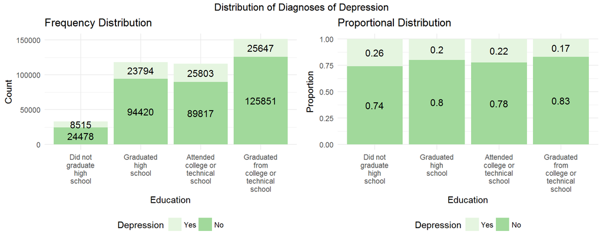

Figure 11: Marginal frequencies and proportions of depression diagnoses by education level completed

The mosaic plot below graphically depicts the association between depression diagnoses and education levels, vis-a-vis the independence model.

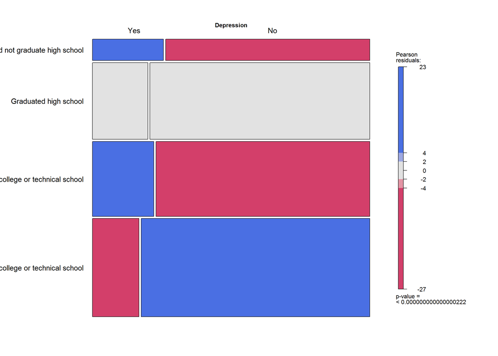

Figure 12: Mosaic plot of marginal relationship between depression and education

As shown in Figure 12, the numbers of observed diagnoses of depression among those that did not graduate from high school, and those that attended college or technical school were greater than expected under the independence model. Observed and expected frequencies of depression diagnoses among high-school graduates were approximately equal. Finally, observed frequencies of diagnoses of depression among college graduates were lower than expected under independence model.

The differences in proportions were tested for statistical significance with a chi-squared at a significance level of $\alpha$ = .05, under the following hypotheses:

$H_0$: Diagnoses of depression and education level are independent  
$H_a$: Diagnoses of depression and education level are not independent

The differences in proportions were statistically significant, $X^2$ = 1,976.118, $N$ = 418,325, $df$ = 8, and $p$ < .001. The strength of the association using Cramer’s V (Hoel, Wolfowitz, and Cramer 1947) was 0.024.

Table 13: The marginal odds ratios of a diagnosis of depression by education level

| Dimension | Odds |
| --- | --- |
| Did not graduate high school:Graduated high school/Yes:No | 1.38 |
| Graduated high school:Attended college or technical school/Yes:No | 0.88 |
| Attended college or technical school:Graduated from college or technical school/Yes:No | 1.41 |

### Depression by Income, Control by Education (Conditional Association)

The conditional association of income and depression, controlling for education was significant at each level of education. In other words, rates of depression and income were inversely associated, regardless of education level, as Figure 14 presents.

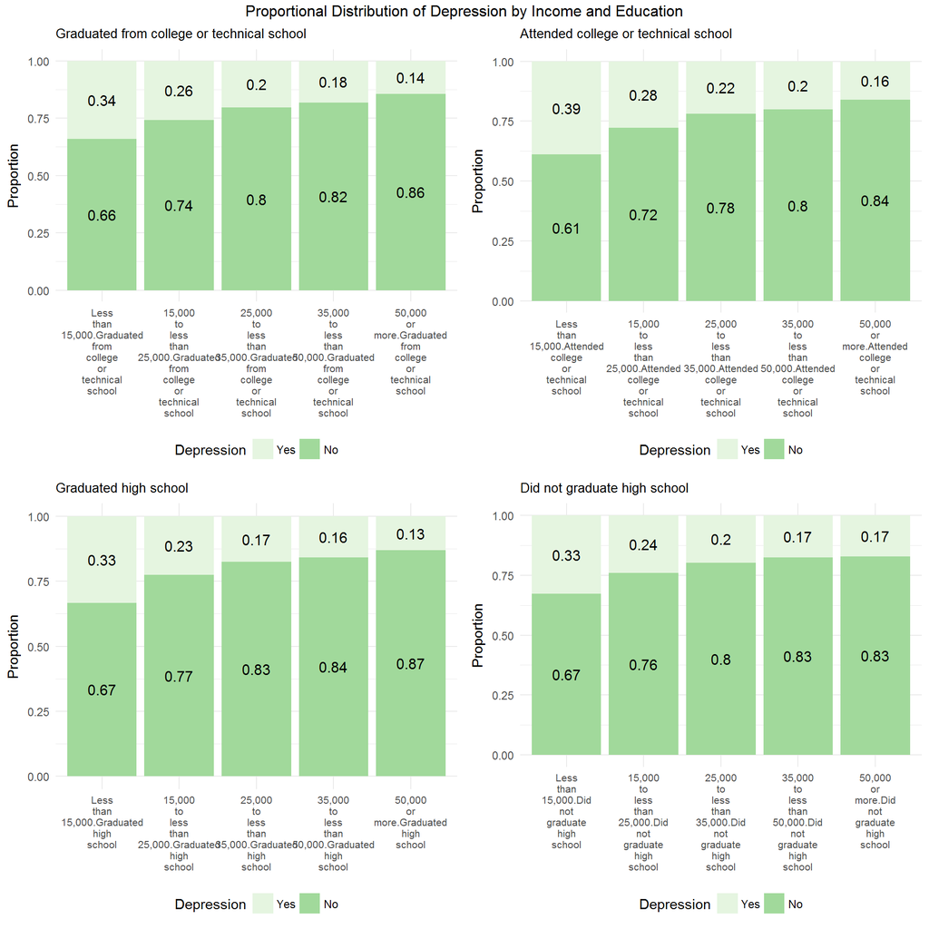

Figure 14: Conditional proportions of depression diagnoses by income, controlling for education

The mosaic plot in Figure 15 graphically depicts the association between depression diagnoses and income levels, controlling for education, vis-a-vis the independence model.

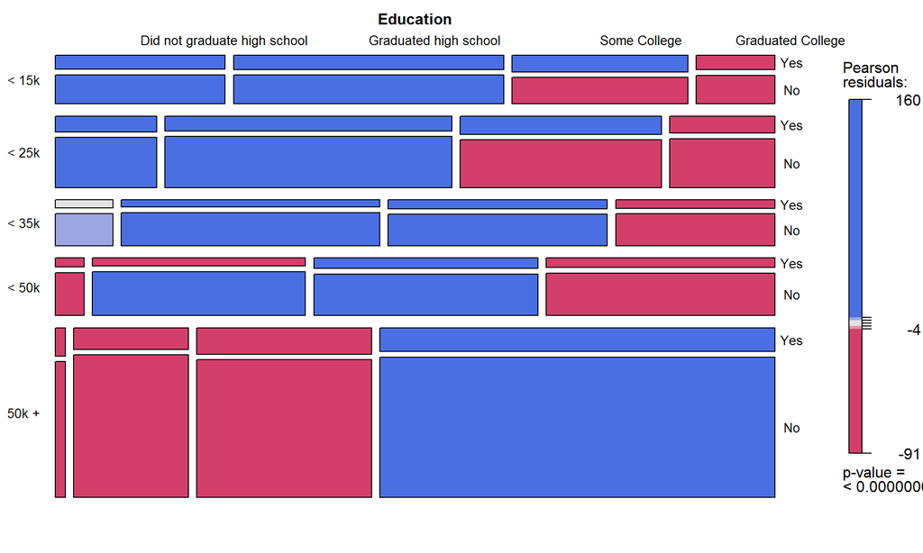

The plot of Pearson residuals in Figure 15 suggests an association between financial compensation and depression at every level of education. The difference in proportions of depression diagnoses among the income categories, controlling for education was tested using the Cochran-Mantel-Haenszel test with a significance level of $\alpha$ = .05, under the following hypotheses:

$H_0$: Diagnoses of depression are independent of income at every level education  
$H_a$: Diagnoses of depression are not independent of income and at every level education

The following tables summarize the conditional association of depression and income at each level of education.

Table 14: Conditional association of depression and income. Stratum: Did not graduate high school

Cochran–Mantel–Haenszel for Depression by Income

| Stratum: Did not graduate high school Parameter | Stratum: Did not graduate high school AltHypothesis | Stratum: Did not graduate high school Chisq | Stratum: Did not graduate high school Df | Stratum: Did not graduate high school Prob |
| --- | --- | --- | --- | --- |
| cor | Nonzero correlation | 521 | 1 | 0 |
| rmeans | Row mean scores differ | 521 | 1 | 0 |
| cmeans | Col mean scores differ | 609 | 4 | 0 |
| general | General association | 609 | 4 | 0 |

Table 15: Conditional association of depression and income. Stratum: Graduated high school

Cochran–Mantel–Haenszel for Depression by Income

| Stratum: Graduated high school Parameter | Stratum: Graduated high school AltHypothesis | Stratum: Graduated high school Chisq | Stratum: Graduated high school Df | Stratum: Graduated high school Prob |
| --- | --- | --- | --- | --- |
| cor | Nonzero correlation | 3073 | 1 | 0 |
| rmeans | Row mean scores differ | 3073 | 1 | 0 |
| cmeans | Col mean scores differ | 3512 | 4 | 0 |
| general | General association | 3512 | 4 | 0 |

Table 16: Conditional association of depression and income. Stratum: Attended college or technical school

Cochran–Mantel–Haenszel for Depression by Income

| Stratum: Attended college or technical school Parameter | Stratum: Attended college or technical school AltHypothesis | Stratum: Attended college or technical school Chisq | Stratum: Attended college or technical school Df | Stratum: Attended college or technical school Prob |
| --- | --- | --- | --- | --- |
| cor | Nonzero correlation | 3276 | 1 | 0 |
| rmeans | Row mean scores differ | 3276 | 1 | 0 |
| cmeans | Col mean scores differ | 3564 | 4 | 0 |
| general | General association | 3564 | 4 | 0 |

Table 17: Conditional association of depression and income. Stratum: Graduated college or technical school

Cochran–Mantel–Haenszel for Depression by Income

| Stratum: Graduated college or technical school Parameter | Stratum: Graduated college or technical school AltHypothesis | Stratum: Graduated college or technical school Chisq | Stratum: Graduated college or technical school Df | Stratum: Graduated college or technical school Prob |
| --- | --- | --- | --- | --- |
| cor | Nonzero correlation | 2393 | 1 | 0 |
| rmeans | Row mean scores differ | 2393 | 1 | 0 |
| cmeans | Col mean scores differ | 2481 | 4 | 0 |
| general | General association | 2481 | 4 | 0 |

Table 22: Conditional odds ratios of depression and income. Stratum: Did not graduate high school

Conditional Odds Ratios for Depression by Income

| Stratum: Did not graduate high school Income | Stratum: Did not graduate high school Odds |
| --- | --- |
| Less than 15,000:15,000 to less than 25,000 | 1.54 |
| 15,000 to less than 25,000:25,000 to less than 35,000 | 1.28 |
| 25,000 to less than 35,000:35,000 to less than 50,000 | 1.16 |
| 35,000 to less than 50,000:50,000 or more | 1.02 |

Table 23: Conditional odds ratios of depression and income. Stratum: Graduated high school

Conditional Odds Ratios for Depression by Income

| Stratum: Graduated high school Income | Stratum: Graduated high school Odds |
| --- | --- |
| Less than 15,000:15,000 to less than 25,000 | 1.71 |
| 15,000 to less than 25,000:25,000 to less than 35,000 | 1.38 |
| 25,000 to less than 35,000:35,000 to less than 50,000 | 1.13 |
| 35,000 to less than 50,000:50,000 or more | 1.24 |

Table 24: Conditional odds ratios of depression and income. Stratum: Attended college or technical school

Conditional Odds Ratios for Depression by Income

| Stratum: Attended college or technical school Income | Stratum: Attended college or technical school Odds |
| --- | --- |
| Less than 15,000:15,000 to less than 25,000 | 1.66 |
| 15,000 to less than 25,000:25,000 to less than 35,000 | 1.36 |
| 25,000 to less than 35,000:35,000 to less than 50,000 | 1.11 |
| 35,000 to less than 50,000:50,000 or more | 1.33 |

Table 25: Conditional odds ratios of depression and income. Stratum: Graduated college or technical school

Conditional Odds Ratios for Depression by Income

| Stratum: Graduated college or technical school Income | Stratum: Graduated college or technical school Odds |
| --- | --- |
| Less than 15,000:15,000 to less than 25,000 | 1.49 |
| 15,000 to less than 25,000:25,000 to less than 35,000 | 1.35 |
| 25,000 to less than 35,000:35,000 to less than 50,000 | 1.16 |
| 35,000 to less than 50,000:50,000 or more | 1.33 |

### Depression and Income and Education (Joint Association)

Is there a joint association between income and scholastic achievement and diagnoses of depression? The association is affirmed by this analysis with a statistical significance of $X^2$ ($df$ = 40, $N$ = 418,325) = 12,268, $p$ < .001. The overall strength of the association using Cramer’s V (Hoel, Wolfowitz, and Cramer 1947) was 0.061.

The combined response rate of the income, education, and depression variables was 85.1%, yielding 418,325 completed cases for analysis. Table 26 and Table 27 show the frequencies and proportions of depression diagnoses by the combination of income and education.

Table 26: Contingency table of frequencies of depression diagnoses by income and education levels

|  |  | Depression | Yes | No |
| --- | --- | --- | --- | --- |
| Income | Education |  |  |  |
| Less than 15,000 | Did not graduate high school |  | 4,145 | 8,510 |
|  | Graduated high school |  | 6,695 | 13,428 |
|  | Attended college or technical school |  | 5,099 | 7,995 |
|  | Graduated from college or technical school |  | 1,999 | 3,866 |
| 15,000 to less than 25,000 | Did not graduate high school |  | 2,678 | 8,455 |
|  | Graduated high school |  | 7,087 | 24,297 |
|  | Attended college or technical school |  | 6,102 | 15,924 |
|  | Graduated from college or technical school |  | 2,977 | 8,577 |
| 25,000 to less than 35,000 | Did not graduate high school |  | 797 | 3,233 |
|  | Graduated high school |  | 3,160 | 14,924 |
|  | Attended college or technical school |  | 3,366 | 11,970 |
|  | Graduated from college or technical school |  | 2,277 | 8,872 |
| 35,000 to less than 50,000 | Did not graduate high school |  | 444 | 2,097 |
|  | Graduated high school |  | 2,958 | 15,836 |
|  | Attended college or technical school |  | 3,979 | 15,759 |
|  | Graduated from college or technical school |  | 3,669 | 16,519 |
| 50,000 or more | Did not graduate high school |  | 451 | 2,183 |
|  | Graduated high school |  | 3,894 | 25,935 |
|  | Attended college or technical school |  | 7,257 | 38,169 |
|  | Graduated from college or technical school |  | 14,725 | 88,017 |

Table 27: Contingency table of proportions of depression diagnoses by income and education levels

|  |  | Depression | Yes | No |
| --- | --- | --- | --- | --- |
| Income | Education |  |  |  |
| Less than 15,000 | Did not graduate high school |  | 0.08012 | 0.16449 |
|  | Graduated high school |  | 0.12940 | 0.25954 |
|  | Attended college or technical school |  | 0.09856 | 0.15453 |
|  | Graduated from college or technical school |  | 0.03864 | 0.07472 |
| 15,000 to less than 25,000 | Did not graduate high school |  | 0.03519 | 0.11111 |
|  | Graduated high school |  | 0.09313 | 0.31929 |
|  | Attended college or technical school |  | 0.08019 | 0.20926 |
|  | Graduated from college or technical school |  | 0.03912 | 0.11271 |
| 25,000 to less than 35,000 | Did not graduate high school |  | 0.01640 | 0.06652 |
|  | Graduated high school |  | 0.06502 | 0.30708 |
|  | Attended college or technical school |  | 0.06926 | 0.24630 |
|  | Graduated from college or technical school |  | 0.04685 | 0.18256 |
| 35,000 to less than 50,000 | Did not graduate high school |  | 0.00725 | 0.03423 |
|  | Graduated high school |  | 0.04829 | 0.25850 |
|  | Attended college or technical school |  | 0.06495 | 0.25724 |
|  | Graduated from college or technical school |  | 0.05989 | 0.26965 |
| 50,000 or more | Did not graduate high school |  | 0.00250 | 0.01209 |
|  | Graduated high school |  | 0.02156 | 0.14358 |
|  | Attended college or technical school |  | 0.04018 | 0.21131 |
|  | Graduated from college or technical school |  | 0.08152 | 0.48728 |

The mosaic plot below reveals significant differences in proportions of depression diagnoses, vis-a-vis the proportions expected under the independence model.

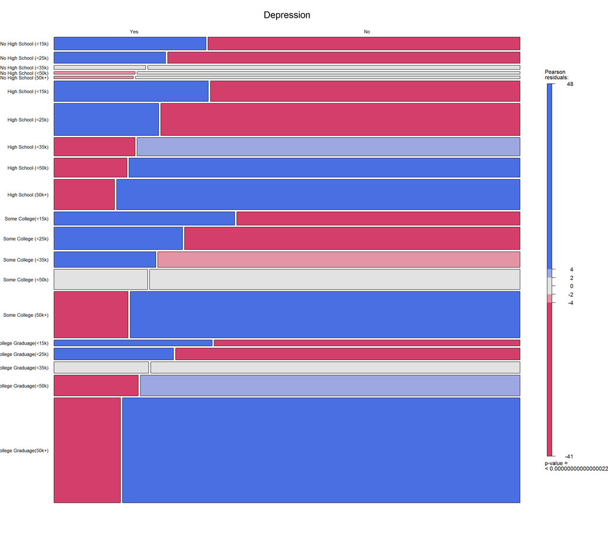

Figure 16: Mosaic plot of joint association between depression and income and education

In Figure 16, blue indicates that the observed frequencies were greater than the expected frequencies under the independence mode, red means that the observed frequencies were fewer than the expected frequencies.

The differences in proportions were tested for statistical significance with a chi-squared at a significance level of $\alpha$ = .05, under the following hypotheses:

$H_0$: Income and education are jointly independent of diagnoses of depression  
$H_a$: Income and education are not jointly independent of diagnoses of depression

The differences in proportions were statistically significant, $X^2$ (40, $N$ = 418,325) = 12,268, $p$ < .001. The overall strength of the association using Cramer’s V (Hoel, Wolfowitz, and Cramer 1947) was 0.061. Nonetheless, the null hypothesis of joint independence was rejected.

Odds ratios were calculated (Table 28) to determine the strength of the association.

Table 28: Joint odds ratios of depression and income and education.

| Income | Odds |
| --- | --- |
| **Did not graduate high school/Yes:No** |  |
| Less than 15,000 / 15,000 to less than 25,000 :Yes/No | 1.54 |
| 15,000 to less than 25,000 / 25,000 to less than 35,000 :Yes/No | 1.28 |
| 25,000 to less than 35,000 / 35,000 to less than 50,000 :Yes/No | 1.16 |
| 35,000 to less than 50,000 / 50,000 or more :Yes/No | 1.02 |
| 50,000 or more / Less than 15,000 :Yes/No | 0.41 |
| **Graduate high school/Yes:No** |  |
| Less than 15,000 / 15,000 to less than 25,000 :Yes/No | 1.71 |
| 15,000 to less than 25,000 / 25,000 to less than 35,000 :Yes/No | 1.38 |
| 25,000 to less than 35,000 / 35,000 to less than 50,000 :Yes/No | 1.13 |
| 35,000 to less than 50,000 / 50,000 or more :Yes/No | 1.24 |
| 50,000 or more / Less than 15,000 :Yes/No | 0.24 |
| **Attended college or technical school/Yes:No** |  |
| Less than 15,000 / 15,000 to less than 25,000 :Yes/No | 1.66 |
| 15,000 to less than 25,000 / 25,000 to less than 35,000 :Yes/No | 1.36 |
| 25,000 to less than 35,000 / 35,000 to less than 50,000 :Yes/No | 1.11 |
| 35,000 to less than 50,000 / 50,000 or more :Yes/No | 1.33 |
| 50,000 or more / Less than 15,000 :Yes/No | 0.37 |
| **Graduated college or technical school/Yes:No** |  |
| Less than 15,000 / 15,000 to less than 25,000 :Yes/No | 1.49 |
| 15,000 to less than 25,000 / 25,000 to less than 35,000 :Yes/No | 1.35 |
| 25,000 to less than 35,000 / 35,000 to less than 50,000 :Yes/No | 1.16 |
| 35,000 to less than 50,000 / 50,000 or more :Yes/No | 1.33 |

To wrap up, the data support the presence of marginal, conditional and joint associations between depression diagnosis and income and education. Income was inversely associated with rates of depression $X^2$ = 11,501.38, $N$ = 418,325, $df$ = 10, and $p < .001$. The strength of the association using Cramer’s V (Hoel, Wolfowitz, and Cramer 1947) was 0.059. Rates of depression diagnoses were also marginally associated with education level completed $X^2$ = 1,976.118, $N$ = 418,325, $df$ = 8, and $p$ < .001. The strength of the association using Cramer’s V (Hoel, Wolfowitz, and Cramer 1947) was 0.024.Conditional associations between rates of depression and income were extant at each level of education with a significance of $p$ < .001. Lastly, income and education were found to be jointly associated with depression diagnoses $X^2$ (40, $N$ = 418,325) = 12,268, $p$ < .001. The overall strength of the association using Cramer’s V (Hoel, Wolfowitz, and Cramer 1947) was 0.061.

## Research Question #2: Depression and Chronic Disease

Is there a relationship between depression and chronic illness? According to this analysis, chronic disease was associated with depression with a statistical significance of , $X^2$ (1, $N$ = 489,486) = 13,257, $p < .001$. The likelihood of a diagnosis of a chronic condition with depression, was 2.45 times the likelihood of a diagnosis of chronic disease without a diagnosis of depression.

Table 29, Table 30 and Figure 17 present a total of 489,486 responses. Of those reporting a diagnosis of depression, 72.8% also had diagnoses of chronic illness. The proportion of diagnoses of chronic illness among those not reporting a prior diagnosis of depression dropped significantly to 52.3%.

Table 29: Depression and chronic illness contingency table

|  | Chronic | Yes | No |
| --- | --- | --- | --- |
| Depression |  |  |  |
| Yes |  | 69,772 | 26,007 |
| No |  | 205,791 | 187,916 |

Table 30: Depression and chronic illness contingency table

|  | Chronic | Yes | No |
| --- | --- | --- | --- |
| Depression |  |  |  |
| Yes |  | 0.73 | 0.27 |
| No |  | 0.52 | 0.48 |

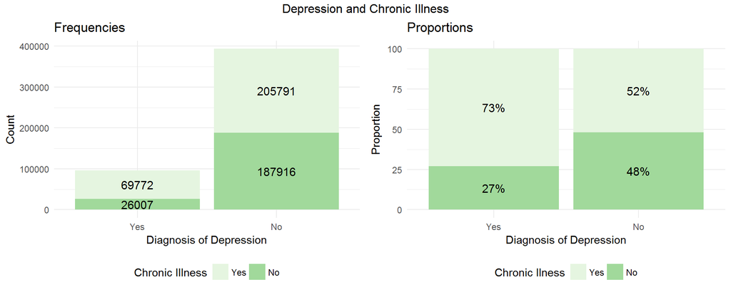

A Pearson’s residuals analysis was administered to assess the relationship between the diagnoses of depression and chronic illness. Figure 18 shows a positive correlation between the two variables, n = 489,486, $p$ < 0.001. The colors indicate the degree of departure of the observed frequencies from expected frequencies under the model of independence. Blue indicates observed frequencies were greater than expected values; whereas, red denotes observed frequencies were less than expected.

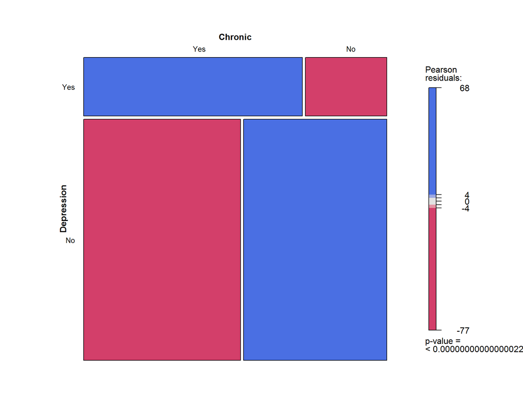

Figure 18: Mosaic plot of depression and chronic illness association

A chi-squared test of independence was administered with a significance level $\alpha$ = .05, under the following hypotheses:

$H_0$: Diagnoses of depression and chronic illness are independent  
$H_a$: Diagnoses of depression and chronic illness are not independent

In conclusion, the differences in proportions were statistically significant, $X^2$ (1, $N$ = 489,486) = 13,257, $p < .001$. The strength of the association using Cramer’s V (Hoel, Wolfowitz, and Cramer 1947) was 0.165. The likelihood of a diagnosis of chronic illness with depression, was 2.45 times the likelihood of a diagnosis of chronic illness without a diagnosis of depression.

## Research Question #3: Depression, Chronic Illness and Productivity

Is there a relationship between depression, chronic illness, and productivity? Marginally speaking, those with a diagnosis of depression reported 121.9% more sick days than those without a diagnosis. The average marginal effect of a diagnosis of chronic illness was 170.2% on the number of sick days. The greatest effect was observed among those with diagnoses of both depression and chronic illness. This group reported 92.4% more sick days than those with a single diagnosis of either depression or one or more chronic conditions.

### Depression and Productivity

What is the effect of depression on productivity? The descriptive statistics in Table 31 reveal a difference of 4.67 days on average, a significant result as the following analysis shows.

Table 31: Descriptive Statistics of Sick Days by Depression Diagnosis

| Variable | Depression | N | Min | Lower | Median | Mode | Mean | CI | Upper | Max | Range | Total | SD | SE | Skew | Kurtosis |
| --- | --- | --- | --- | --- | --- | --- | --- | --- | --- | --- | --- | --- | --- | --- | --- | --- |
| SickDays | Yes | 75791 | 0 | 0 | 2 | 0 | 8.50 | 0.079 | 15 | 30 | 30 | 643972 | 11.06 | 0.04 | 1.03 | -0.50 |
| SickDays | No | 171338 | 0 | 0 | 0 | 0 | 3.83 | 0.039 | 3 | 30 | 30 | 656886 | 8.16 | 0.02 | 2.40 | 4.54 |

Figure 19 illuminates the frequency and proportions of reports of sick days vis-a-vis a diagnosis of depression. A total of 106,375 reported one or more sick days, of that number 41.4% reported a diagnosis of depression. That said, the bar chart on the right reveals that a respondent with a diagnosis of depression was 2.43 times as likely to have one or more sick days in a month than those without a diagnosis of depression.

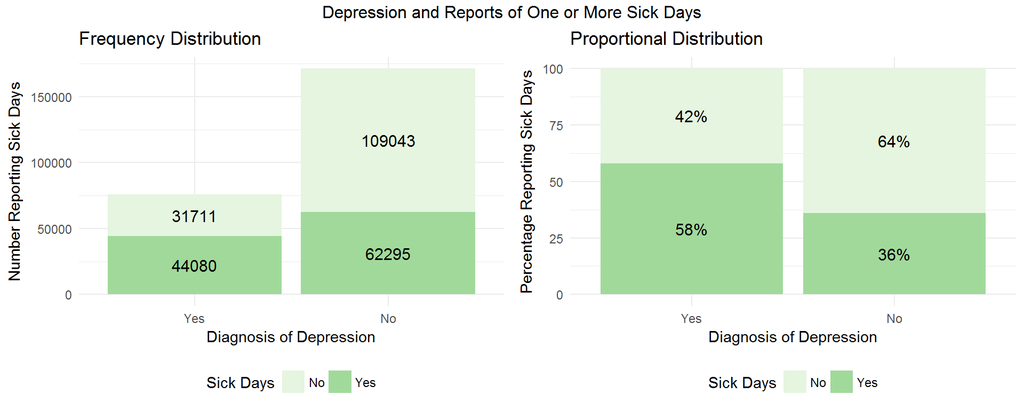

Figure 19: Depression and Reports of Health-Related Restricted Activity

Next, the distributions of sick days between the groups are examined.

[figure not shown]

Figure 20: Distribution Summary of Reports of Sick Days by Diagnosis of Depression

As indicated in Figure 20 the distribution of sick days for those reporting diagnoses of depression was more narrow in the extremes, with a substantially larger interquartile range. For the group without diagnoses of depression, the reported sick days more closely centered around its median of zero days.

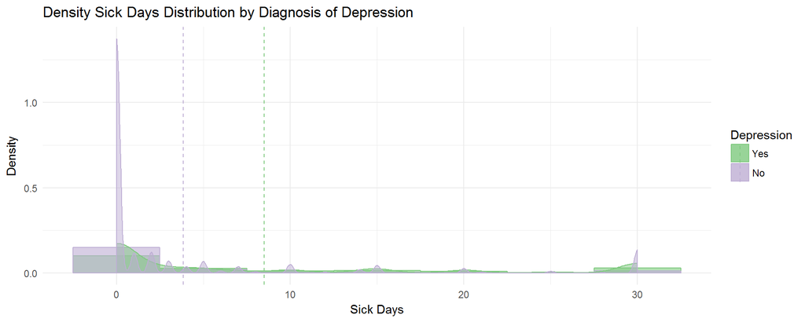

Figure 21: Distribution of Sick Days by Diagnosis of Depression

As implied by Figure 20, both distributions peak at zero days; however, the group without depression had substantially higher reports of zero sick days. To get a better sense of the distribution, reports of zero sick days were removed from the data set and a new density plot was rendered. As Figure 21 reveals, the group reporting depression had higher frequencies of reports of longer bouts of restricted activity.

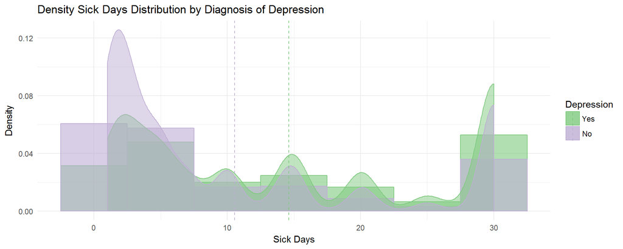

Figure 21: Distribution of One or More Sick Days by Diagnosis of Depression

$H_0$ The distributions of both populations are equal  
$H_a$ The distributions of both populations are not equal

### Chronic Illness and Productivity

What is the effect of chronic disease on productivity? Table 32 exhibits a 4.29 day difference in the mean number sick days. The following analysis explores the significance and effect of this difference.

Table 32: Descriptive Statistics of Restricted Activity Days by Chronic Disease Diagnosis

| Variable | Chronic | N | Min | Lower | Median | Mode | Mean | CI | Upper | Max | Range | Total | SD | SE | Skew | Kurtosis |
| --- | --- | --- | --- | --- | --- | --- | --- | --- | --- | --- | --- | --- | --- | --- | --- | --- |
| SickDays | Yes | 159477 | 0 | 0 | 0 | 0 | 6.81 | 0.051 | 10 | 30 | 30 | 1086552 | 10.46 | 0.026 | 1.38 | 0.37 |
| SickDays | No | 89144 | 0 | 0 | 0 | 0 | 2.52 | 0.041 | 2 | 30 | 30 | 224364 | 6.26 | 0.021 | 3.29 | 10.57 |

The frequency and proportion tables in Figure 22 cite a total of 107,115 respondents who reported one or more sick days, of that number 72.4% reported a diagnosis of chronic illness. Respondents with a diagnosis of chronic illness were 1.91 times as likely to have one or more sick days in a month than those without a diagnosis of chronic illness.

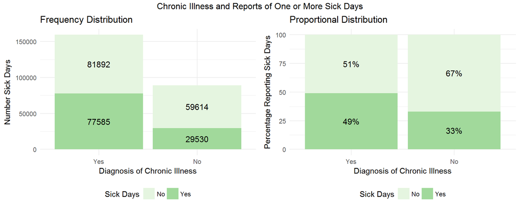

Figure 22: Chronic Illness and Reports of Health-Related Restricted Activity

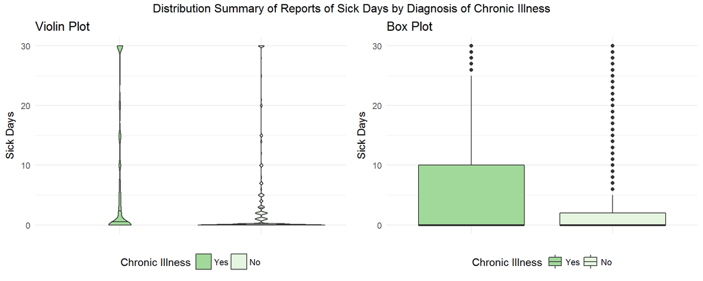

Figure 23: Distribution Summary of Reports of Sick Days by Diagnosis of Chronic Illness

The violin and box plots in Figure 23 show two different distributions, one characterized by a relatively wide spread, the other centered around its median of zero days. The group reporting chronic illness reported up to ten sick days, 75% of the time; whereas, the other group reported no more than two sick days, 75% of the time.

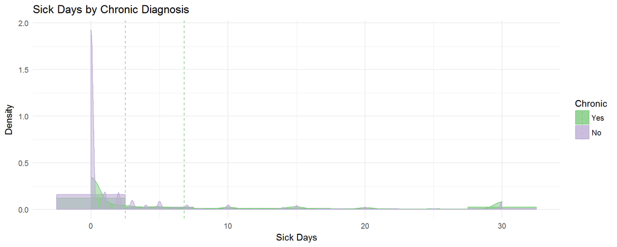

Figure 24: Distribution of Sick Days by Diagnosis of Chronic Illness

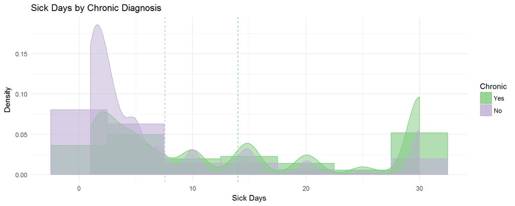

### Depression Chronic Illness and Productivity

Table 33 and Table 34 outline the frequencies and proportions reporting sick days over the month preceding the survey, by diagnoses of chronic conditions or depression. Of a total of 247,129 respondents, 43% reported one or more sick days during the month preceding the survey and 33.1% of that group had diagnoses of both depression and chronic illness.

Table 33: Frequencies of Reports of Health-Related Restricted Activity, Depression, and Chronic Illness

|  |  | SickDaysInd | No | Yes |
| --- | --- | --- | --- | --- |
| Depression | Chronic |  |  |  |
| Yes | Yes |  | 21,349 | 35,159 |
|  | No |  | 10,362 | 8,921 |
| No | Yes |  | 60,095 | 41,935 |
|  | No |  | 48,948 | 20,360 |

Table 34: Proportions of Reports of Health-Related Restricted Activity, Depression, and Chronic Illness

|  |  | SickDaysInd | No | Yes |
| --- | --- | --- | --- | --- |
| Depression | Chronic |  |  |  |
| Yes | Yes |  | 0.2816825 | 0.4638941 |
|  | No |  | 0.1367181 | 0.1177053 |
| No | Yes |  | 0.3507395 | 0.2447501 |
|  | No |  | 0.2856809 | 0.1188294 |

Figure 26 illuminates the degree to which the frequencies of reports depart from expected under the independence model. If the null hypothesis of the independence of chronic illness and depression from productivity held, those with chronic illness and depression diagnoses would report fewer sick days and those without a diagnosis of depression, either with or without chronic illness would have reported more sick days.

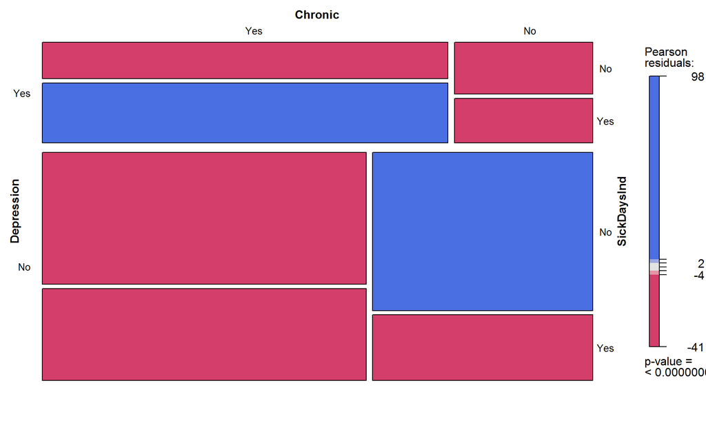

Figure 26: Mosaic plot of depression, chronic illness, and productivity

Table 35 reveals significant differences in mean number of sick days reported by diagnosis. Naturally, those with neither diagnosis reported the lowest number of restricted activity days; however, the number increased 133% for those having either a diagnosis of depression or one or more chronic conditions. Those reporting both diagnoses reported, on average, 92.4% more sick days than those having a single diagnosis of either depression or one or more chronic conditions.

Table 35: Descriptive Statistics of Restricted Activity Days by Chronic Disease and Depression Diagnoses

| Variable | DepressionChronic | N | Min | Lower | Median | Mode | Mean | CI | Upper | Max | Range | Total | SD | SE | Skew | Kurtosis |
| --- | --- | --- | --- | --- | --- | --- | --- | --- | --- | --- | --- | --- | --- | --- | --- | --- |
| SickDays | Yes.Yes | 56508 | 0 | 0 | 4 | 0 | 9.85 | 0.095 | 20 | 30 | 30 | 556721 | 11.56 | 0.049 | 0.79 | -0.98 |
| SickDays | No.Yes | 102030 | 0 | 0 | 0 | 0 | 5.12 | 0.057 | 5 | 30 | 30 | 522165 | 9.37 | 0.029 | 1.87 | 2.06 |
| SickDays | Yes.No | 19283 | 0 | 0 | 0 | 0 | 4.52 | 0.116 | 5 | 30 | 30 | 87251 | 8.22 | 0.059 | 2.11 | 3.40 |
| SickDays | No.No | 69308 | 0 | 0 | 0 | 0 | 1.94 | 0.040 | 1 | 30 | 30 | 134721 | 5.44 | 0.021 | 3.95 | 16.03 |

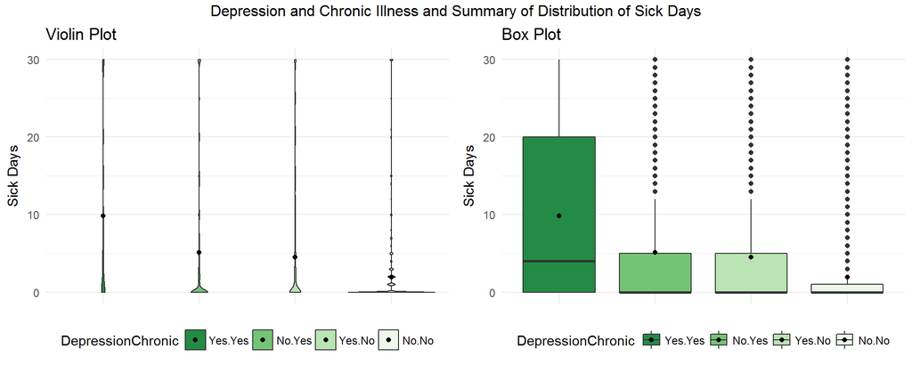

Figure 27: Distribution Summary of Reports of Sick Days by Diagnosis of Chronic Illness & Depression

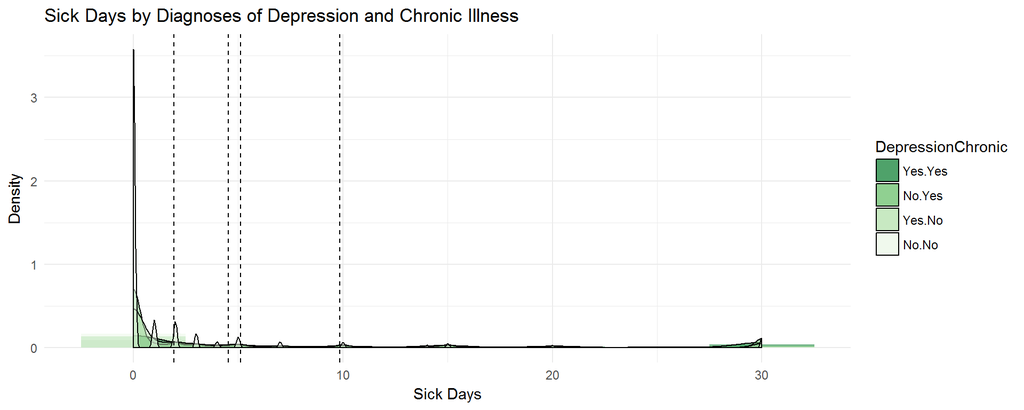

Figure 28: Distribution of Sick Days by Diagnosis of Chronic Illness and Depression

The distribution depicted in Figure 28 is distorted by heavy right skew and the reports of zero sick days. Removing the reports of zero sick days from the data set exposed the shape of the distribution of reports of one or more days of health-related restricted activity.

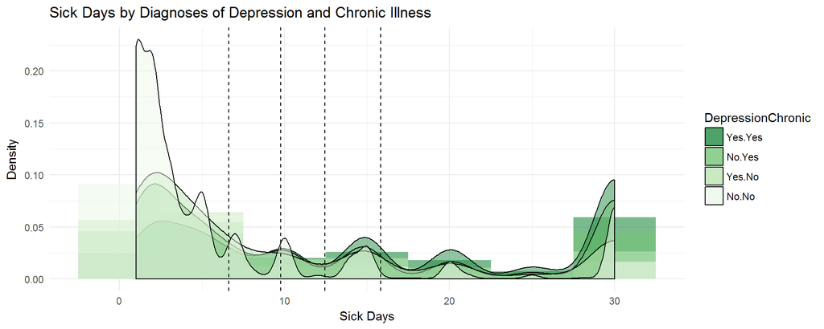

Figure 29: Distribution of Sick Days by Diagnosis of Chronic Illness and Depression

The white in Figure 29 represents the reports of those with neither diagnosis and the dark green end of the spectrum symbolizes the reports of those with both diagnoses. The left side is dominated by light colors, representing those without either diagnosis reporting between zero and five sick days during the month preceding the survey. Moving right, the plot gets darker with increasing reports from those with one or both diagnoses of longer periods of restricted activity.

Figure 30 illustrates how the effect of chronic illness on productivity depends upon the occurrence of a diagnosis of depression.

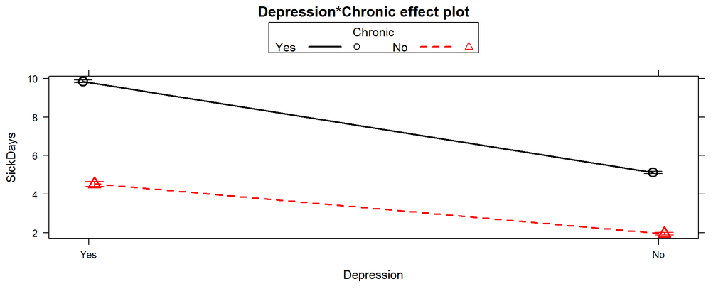

Figure 30: Interaction between the diagnoses of depression and chronic illness and their effects on productivity.

$H_0$ There is no difference in each group’s effect on productivity  
$H_a$ There is a difference in each group’s effect on productivity

As expected, there were significant differences in the number of sick days among the four scenarios, $X^2$ = 20,899.56, $p$ < .001, $df$ = 3. To determine which scenario had the greatest effect on productivity, several pairwise post hoc Mann-Whitney-Wilcoxon tests were administered at a significance of $\alpha$ = .05, under the following hypotheses.

$H_0$ There is no difference in the number of sick days between those without diagnoses of chronic illness and depression and those with a diagnosis of depression, without concurrent chronic illness  
$H_0$ There is no difference in the number of sick days between those with a diagnosis of depression, without concurrent chronic illness and those with a diagnosis of chronic illness, without concurrent depression  
$H_0$ There is no difference in the number of sick days between those with a diagnosis of chronic illness, without concurrent depression and those with both diagnoses  
$H_a$ There is a difference in the number of sick days between those without diagnoses of chronic illness and depression and those with a diagnosis of depression, without concurrent chronic illness  
$H_a$ There is a difference in the number of sick days between those with a diagnosis of depression, without concurrent chronic illness and those with a diagnosis of chronic illness, without concurrent depression  
$H_a$ There is a difference in the number of sick days between those with a diagnosis of chronic illness, without concurrent depression and those with both diagnoses

The results of the tests are summarized in Table 36.

Table 36: Pairwise Mann-Whitney-Wilcoxon tests of depression and chronic illness on productivity

| Test | Group A A.Depression | Group A A.Chronic | Group B B.Depression | Group B B.Chronic | X2 | p | Estimate | Lower_CI | Upper_CI | Effect |
| --- | --- | --- | --- | --- | --- | --- | --- | --- | --- | --- |
| 1 | Yes | Yes | No | Yes | 3631223806 | 0 | 0.9999679 | 0.9999495 | 0.9999887 | 0.2281166 |
| 2 | No | Yes | Yes | No | 957701140 | 0 | -0.0000128 | -0.0000330 | -0.0000699 | 0.0516289 |
| 3 | Yes | No | No | No | 802546700 | 0 | 0.0000242 | 0.0000264 | 0.0000242 | 0.1768719 |

The differences in the effect on productivity were significant, $X^2$ from 802,546,700 to 3,631,223,806, $p$ < .001. As hypothesized, the largest positive effect size and location parameter were between the reports from those with both diagnoses and those with only one.

Which chronic diseases have the greatest impact on productivity? The following bar chart depicts the mean number of sick days reported for the 30 days preceding the survey, by condition.

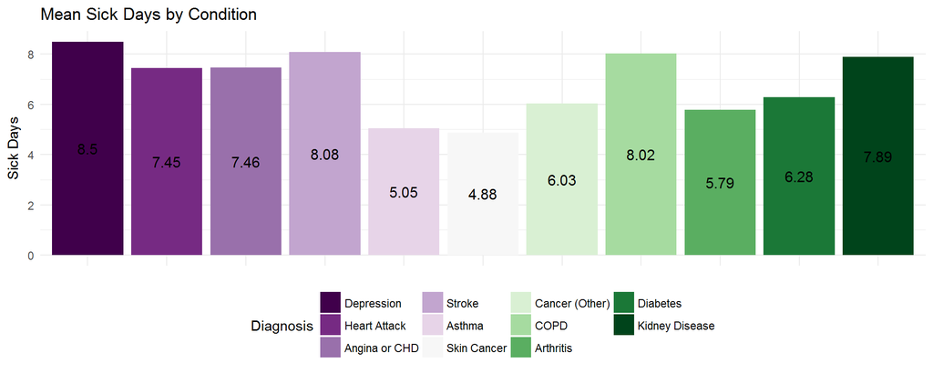

Figure 31: Sick days during preceding 30 days by chronic condition

Of the ten chronic diseases analyzed, depression had the greatest impact on productivity, reporting 5.2% more sick days than stroke, the second most impacting condition and 27% greater productivity loss than the average of all chronic conditions.